# Titanic - Exploratory Analysis

Fabrice Tereszkiewicz

29 Sep 2015

# Titanic: Machine Learning from Disaster

## Introduction

The Kaggle competition “Titanic: Machine Learning from Disaster” offers the opportunity to analyse the outcome of the Titanic disaster. We have access to the list of passengers who survived or not along with information regarding their situation (passenger class, travelled alone or in family, etc..).

The goal is to build a model to predict if a passenger survived based on this data. We will first look at the raw data to get a better picture of the parameters that are more or less correlated with the survival of the passenger. Also we’ll study the different features in order to determine if more information can be obtained by derivation.

## Loading data

The data is in CSV format. You must download it from the Kaggle competition and place it in a `data` folder. I also load the test data, may be handy if we decide some transformation.

```r
df <- read.csv2('../data/train.csv', sep = ',')
df_test <- read.csv2('../data/test.csv', sep=',')
```

A quick look at the data:

```r
glimpse(df)
```

```
## Observations: 891
## Variables: 12
## $ PassengerId (int) 1, 2, 3, 4, 5, 6, 7, 8, 9, 10, 11, 12, 13, 14, 15,...
## $ Survived    (int) 0, 1, 1, 1, 0, 0, 0, 0, 1, 1, 1, 1, 0, 0, 0, 1, 0,...
## $ Pclass      (int) 3, 1, 3, 1, 3, 3, 1, 3, 3, 2, 3, 1, 3, 3, 3, 2, 3,...
## $ Name        (fctr) Braund, Mr. Owen Harris, Cumings, Mrs. John Bradl...
## $ Sex         (fctr) male, female, female, female, male, male, male, m...
## $ Age         (fctr) 22, 38, 26, 35, 35, , 54, 2, 27, 14, 4, 58, 20, 3...
## $ SibSp       (int) 1, 1, 0, 1, 0, 0, 0, 3, 0, 1, 1, 0, 0, 1, 0, 0, 4,...
## $ Parch       (int) 0, 0, 0, 0, 0, 0, 0, 1, 2, 0, 1, 0, 0, 5, 0, 0, 1,...
## $ Ticket      (fctr) A/5 21171, PC 17599, STON/O2. 3101282, 113803, 37...
## $ Fare        (fctr) 7.25, 71.2833, 7.925, 53.1, 8.05, 8.4583, 51.8625...
## $ Cabin       (fctr) , C85, , C123, , , E46, , , , G6, C103, , , , , ,...
## $ Embarked    (fctr) S, C, S, S, S, Q, S, S, S, C, S, S, S, S, S, S, Q...
```

We have 891 observations, 12 features.

## Features analysis

### Passenger Id

This is obviously not useful to determine if the passenger survived or not. We will exclude it in the preprocessing stage.

### Survived

This is the outcome of the prediction, we will use it to train our model. This shouldn’t be an `integer` but a factor. Let’s see how many passengers in our dataset survived the disaster:

```r
df$Survived <- as.factor(df$Survived)
survived <- count(df[df$Survived == 1,])$n
died <- count(df[df$Survived == 0,])$n
survival_rate <- round(survived / (survived + died) *100, 2)
d <- data.frame(
    x = factor(c('Survived', 'Died')),
    y = c(count(df[df$Survived == 1,])$n, count(df[df$Survived == 0,])$n)
)
d
```

```
##          x   y
## 1 Survived 342
## 2     Died 549
```

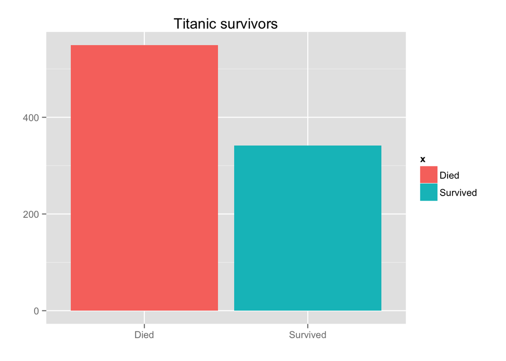

```r
g <- ggplot(d, aes(x=x, y=y))
g <- g + geom_bar(stat='identity', aes(fill=x))
g <- g + labs(title="Titanic survivors", x='', y='')
g
```

We have 342 survivors and 549 passengers who didn’t make it. That’s a 38.38% survivial rate.

### Passenger class

That’s the feature `Pclass` in the dataset. This can be considered a proxy for the social status of the passenger (i.e. 1st class passenger are probably wealthier than 3rd class passengers).

```r
unique(df$Pclass)
```

```
## [1] 3 1 2
```

We have only 3 classes. Let’s make a factor out of it and look at the repartition.

```r
df$Pclass <- as.factor(df$Pclass)
d <- data.frame(
    class = factor(c('1st class', '2nd class', '3rd class')),
    passengers = c(count(df[df$Pclass == 1,])$n,
          count(df[df$Pclass == 2,])$n,
          count(df[df$Pclass == 3,])$n)
)
g <- ggplot(d, aes(x=class, y=passengers))
g <- g + geom_bar(stat='identity', aes(fill=class))
g <- g + labs(title="Passenger class population", x='', y='')
d
```

```
##       class passengers
## 1 1st class        216
## 2 2nd class        184
## 3 3rd class        491
```

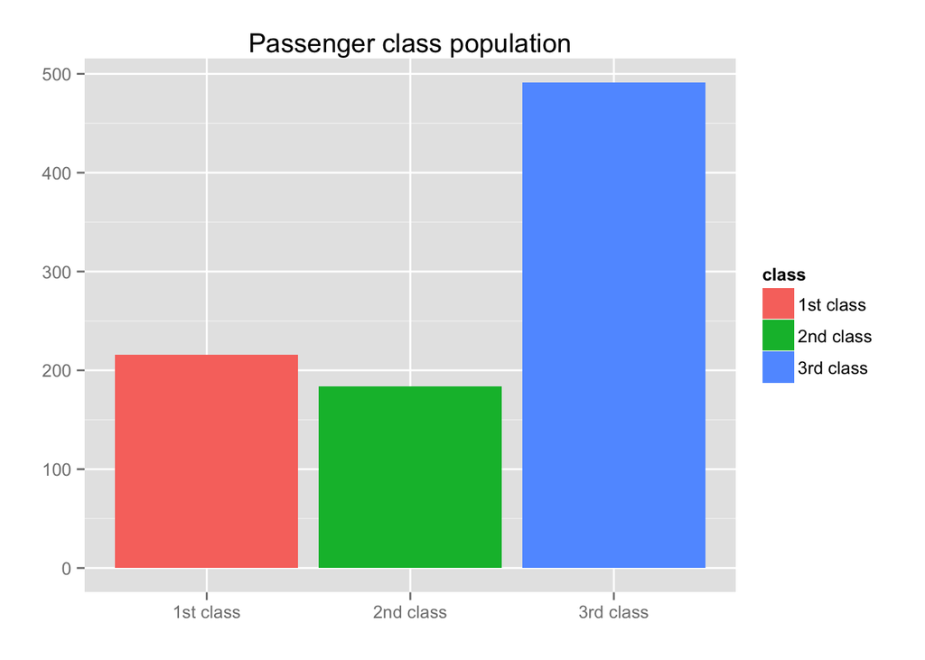

```r
g
```

We can see that the majority of the passengers are in the 3rd class. Let’s see among each class, how many passenger survived the disaster.

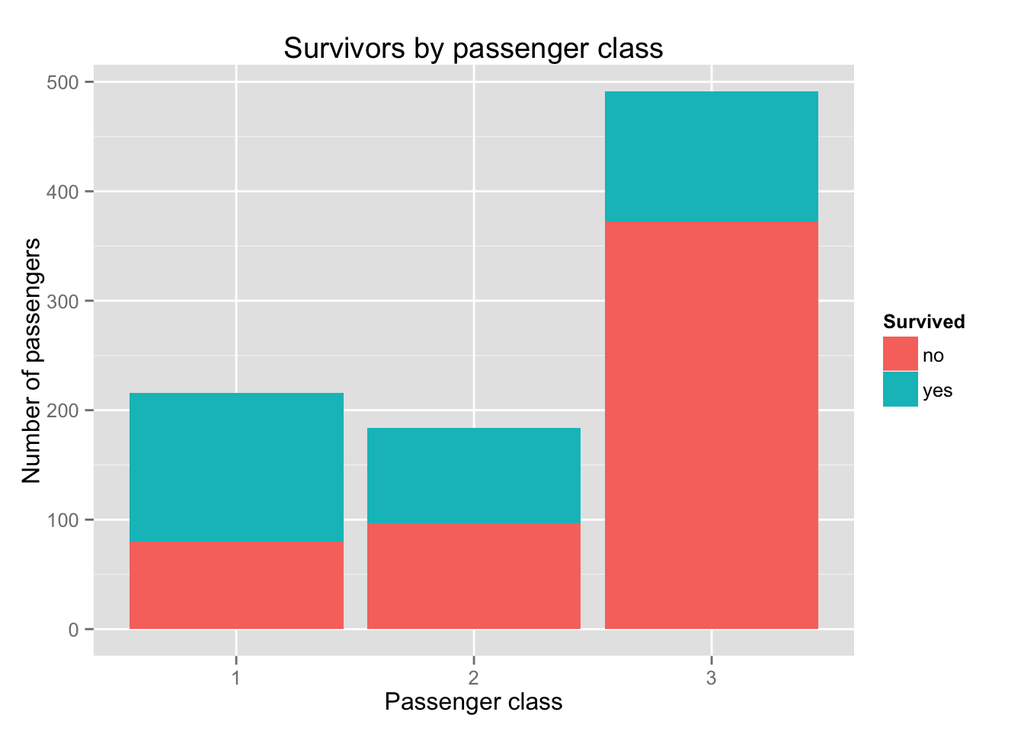

```r
d <- df %>% select(Survived, Pclass)
g <- ggplot(data = d, aes(x=Pclass, fill=Survived))
g <- g + geom_bar()
g <- g + labs(title="Survivors by passenger class", x="Passenger class", y="Number of passengers")
g <- g + scale_fill_discrete(name="Survived", labels=c("no", "yes"))
g
```

We can see that the majority of the passengers in first class survived, so did about half of those in second class. The majority of the losses come from the 3rd class.

The passenger class is therefore to be considered an important feature for our model.

### Passenger name

This feature as it is probably not relevant, but we can still have a look at a few caracteristics and see if we find some correlation with the survival rate. This feature shouldn’t be treated as a factor but as a string.

First, some names have an additional name in brackets. That may also be an indicator of the social status of the passenger. Let’s have a look.

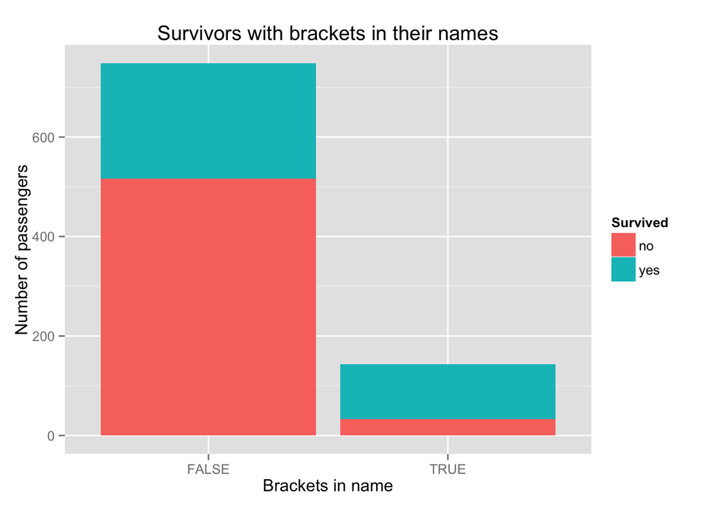

```r
d <- df %>% mutate(AdditionalName = grepl('\\(', Name)) %>% select(Survived, AdditionalName)
g <- ggplot(data = d, aes(x=AdditionalName, fill=Survived))
g <- g + geom_bar()
g <- g + labs(title="Survivors with brackets in their names", x="Brackets in name", y="Number of passengers")
g <- g + scale_fill_discrete(name="Survived", labels=c("no", "yes"))
g
```

Well, it looks like if you have an additional name in brackets, it indeed increase your probability of surviving from the disaster. That’s a feature we can use in our model.

Also some names have a name in quotes, maybe something to look at.

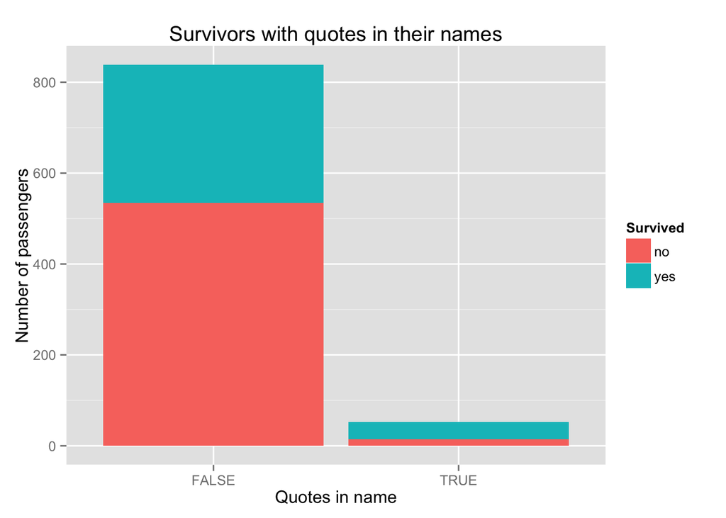

```r
d <- df %>% mutate(QuotedName = grepl('\\"', Name)) %>% select(Survived, QuotedName)
g <- ggplot(data = d, aes(x=QuotedName, fill=Survived))
g <- g + geom_bar()
g <- g + labs(title="Survivors with quotes in their names", x="Quotes in name", y="Number of passengers")
g <- g + scale_fill_discrete(name="Survived", labels=c("no", "yes"))
g
```

Indeed, with quotes, the survival rate is higher than without.

Another information from the name could be the title. Let’s extract them first:

```r
titles <- as.factor(gsub(".*,\\s?\\w*?\\s?(\\w+)\\..*", "\\1", df$Name, perl=TRUE))
test_titles <- as.factor(gsub(".*,\\s?\\w*?\\s?(\\w+)\\..*", "\\1", df_test$Name, perl=TRUE))
levels(titles)
```

```
##  [1] "Capt"     "Col"      "Countess" "Don"      "Dr"       "Jonkheer"
##  [7] "Lady"     "Major"    "Master"   "Miss"     "Mlle"     "Mme"
## [13] "Mr"       "Mrs"      "Ms"       "Rev"      "Sir"
```

```r
summary(titles)
```

```
##     Capt      Col Countess      Don       Dr Jonkheer     Lady    Major
##        1        2        1        1        7        1        1        2
##   Master     Miss     Mlle      Mme       Mr      Mrs       Ms      Rev
##       40      182        2        1      517      125        1        6
##      Sir
##        1
```

Looks like we can do some cleaning, the infered important imformation we can hope to extract from the titels being the sex (we already know) and some kind of social marker. So maybe we can group the “fancy” titles together, and keep sex separation. We can group distinguished male titles into ‘Sir’, keep Mr for the others, and sitinguished female titles into ‘Lady’, maybe stil keep the ‘Mrs’ and ‘Miss’ as well. Also Wikipedia tells us that ‘Jonkheer’ is indeed an honoric title for men : *Jonkheer (female equivalent: Jonkvrouw) is a Dutch honorific of nobility*

Before cleaning up, it may worth having a look at the titles in the test data as well.

```r
summary(test_titles)
```

```
##    Col   Dona     Dr Master   Miss     Mr    Mrs     Ms    Rev
##      2      1      1     21     78    240     72      1      2
```

There is a new ‘Dona’ that we must correctly group as well.

```r
titles[titles %in% c('Rev', 'Dr', 'Jonkheer', 'Major', 'Master', 'Capt', 'Col', 'Don')] = 'Sir'
titles[titles %in% c('Countess', 'Dona')] = 'Lady'
titles[titles %in% c('Mlle', 'Ms')] = 'Miss'
titles[titles == 'Mme'] = 'Mrs'
titles = droplevels(titles)
summary(titles)
```

```
## Lady Miss   Mr  Mrs  Sir
##    2  185  517  126   61
```

Here are the survival rates:

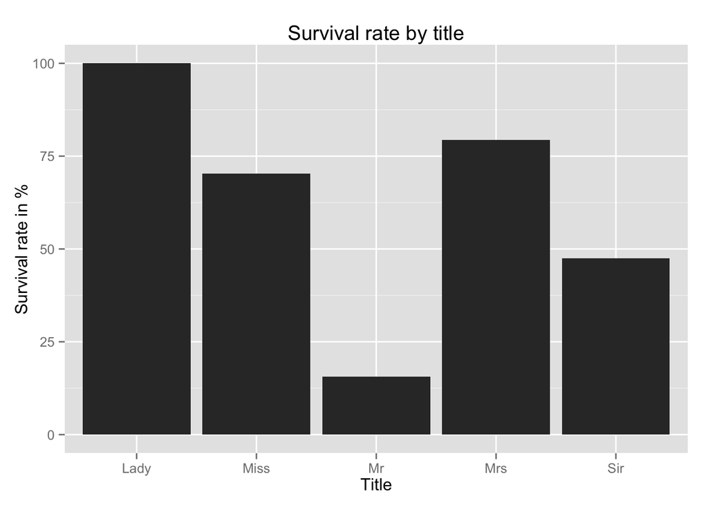

```r
d <- df %>%
    mutate(title = titles) %>%
    select(Survived, title) %>%
    group_by(title, Survived) %>%
    summarise(n = n()) %>%
    mutate(rate = n/sum(n) * 100) %>%
    filter(Survived == 1)
g <- ggplot(data = d, aes(x=title, y=rate))
g <- g + geom_bar(stat='identity')
g <- g + labs(title="Survival rate by title", x="Title", y="Survival rate in %")
g
```

We can see that the survival rate varies by title. `Mr` died the most, and the ``Lady` survived. So this would also be an interesting feature to include in our model. Also… with the little test trick, we can hope that our ‘Dona’ will survive our model.

We can also look at the firstnames, that may be an indication of the social status.

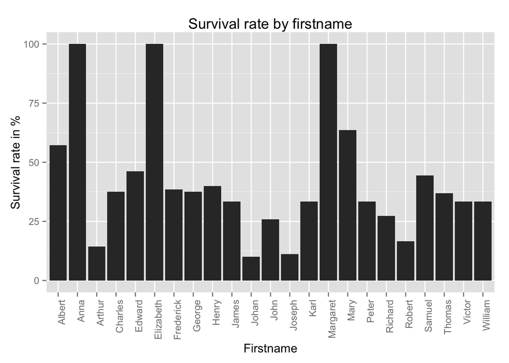

```r
firstname <- as.factor(gsub(".*\\. o?f? ?\\(?(\\w+).*", "\\1", df$Name, perl=TRUE))
d <- df %>% mutate(firstname = firstname)
common_firstnames <- d %>%
    group_by(firstname) %>%
    summarise(count=n()) %>%
    arrange(desc(count)) %>%
    filter(count > 5) %>%
    select(firstname)
d2 <- d %>%
    select(Survived, firstname) %>%
    group_by(firstname, Survived) %>%
    filter(firstname %in% common_firstnames$firstname) %>%
    summarise(n = n()) %>%
    mutate(rate = n/sum(n) * 100) %>%
    filter(Survived == 1)
g <- ggplot(data = d2, aes(x=firstname, y=rate))
g <- g + geom_bar(stat='identity')
g <- g + labs(title="Survival rate by firstname", x="Firstname", y="Survival rate in %")
g <- g + theme(axis.text.x = element_text(angle = 90, hjust = 1))
g
```

### Passenger sex

Male or female, does it have a correlation with the survival rate ?

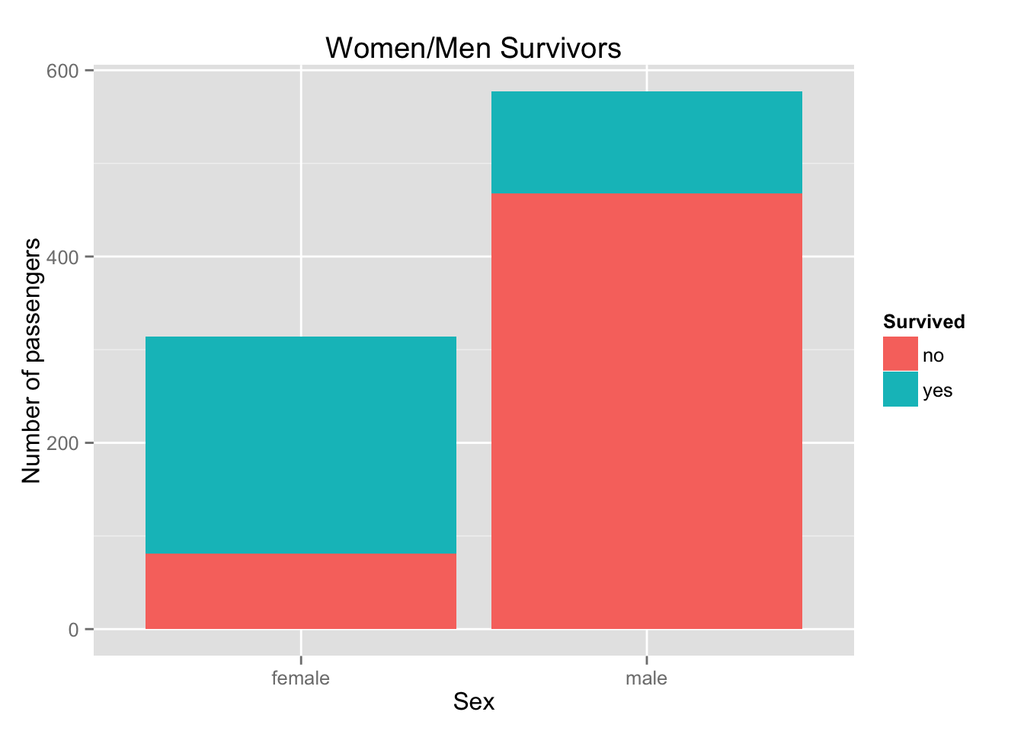

```r
d <- df %>% select(Survived, Sex)
g <- ggplot(data = d, aes(x=Sex, fill=Survived))
g <- g + geom_bar()
g <- g + labs(title="Women/Men Survivors", x="Sex", y="Number of passengers")
g <- g + scale_fill_discrete(name="Survived", labels=c("no", "yes"))
g
```

Ok, looks like female have more chance to survive. This is definitely an important feature for our model.

### Passenger age

We see a few missing values here. Let’s convert this column to numeric and make sure we exclude the NA’s values from this analysis.

```r
df$Age <- as.numeric(as.character(df$Age))
```

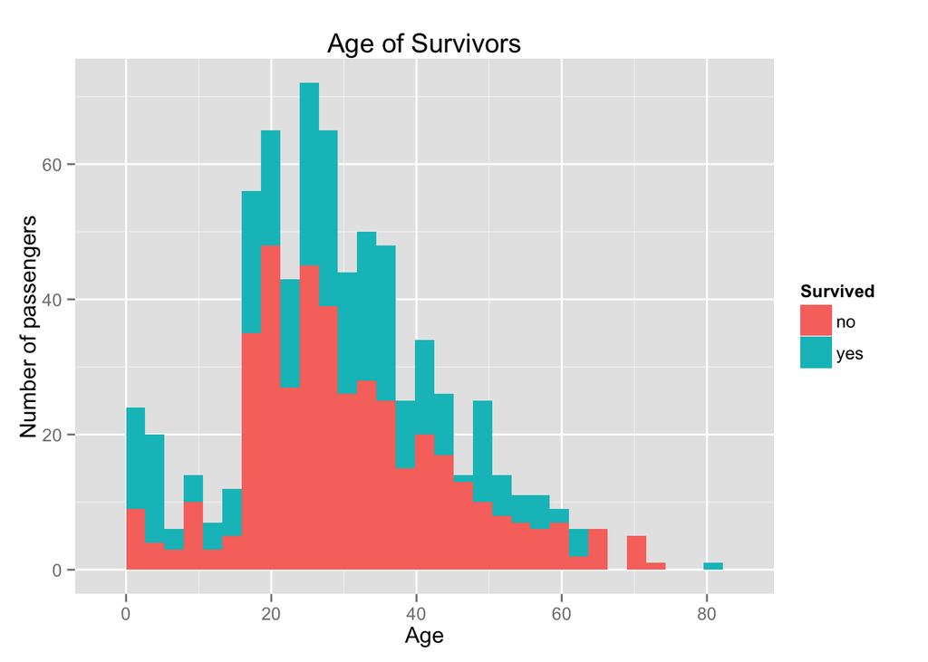

```r
d <- df %>% select(Age, Survived) %>% filter(!is.na(Age))
g <- ggplot(data = d, aes(x=Age, fill=Survived))
g <- g + geom_bar()
g <- g + labs(title="Age of Survivors", x="Age", y="Number of passengers")
g <- g + scale_fill_discrete(name="Survived", labels=c("no", "yes"))
g
```

The passenger age seems a very important feature. We will have to decide a method for filling in the missing values. A simple linear regression model to fill in the missing ages based on other parameters (passenger class, sex, fare…) would probably work fine.

### Number of Siblings/Spouses Aboard

We can se from the data if a passenger has a sibling on board. Does it impact its survival rate ?

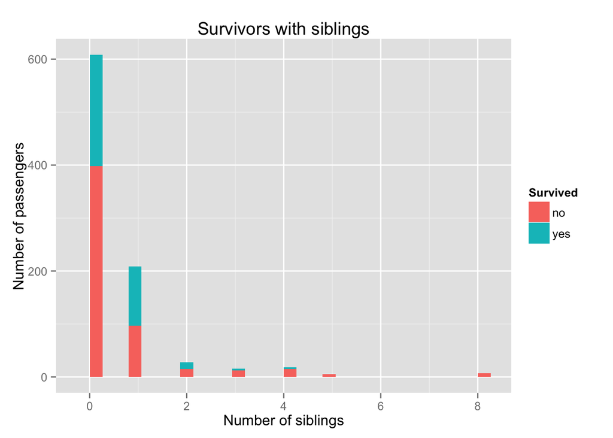

```r
d <- df %>% select(Survived, SibSp)
g <- ggplot(data = d, aes(x=SibSp, fill=Survived))
g <- g + geom_bar()
g <- g + labs(title="Survivors with siblings", x="Number of siblings", y="Number of passengers")
g <- g + scale_fill_discrete(name="Survived", labels=c("no", "yes"))
g
```

### Number of Parents/Children Aboard

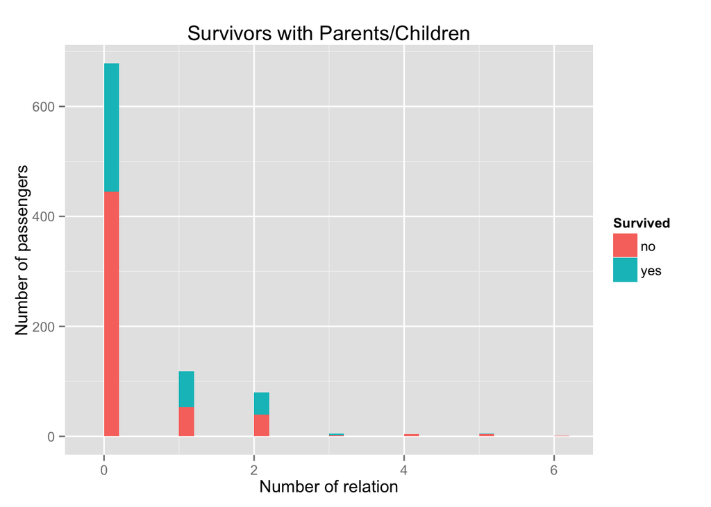

```r
d <- df %>% select(Survived, Parch)
g <- ggplot(data = d, aes(x=Parch, fill=Survived))
g <- g + geom_bar()
g <- g + labs(title="Survivors with Parents/Children", x="Number of relation", y="Number of passengers")
g <- g + scale_fill_discrete(name="Survived", labels=c("no", "yes"))
g
```

This doesn’t look like a very important feature. Maybe that can be used to derive features, copling with the sex for example. Here are the survival rates for mens depending on their relationships:

```r
d <- df %>%
    select(Sex, Survived, Parch) %>%
    filter(Sex == 'male') %>%
    select(Survived, Parch) %>%
    group_by(Parch, Survived) %>%
    summarise(n=n()) %>%
    mutate(rate=n/sum(n) * 100)
d
```

```
## Source: local data frame [9 x 4]
## Groups: Parch [6]
##
##   Parch Survived     n      rate
##   (int)   (fctr) (int)     (dbl)
## 1     0        0   404  83.47107
## 2     0        1    80  16.52893
## 3     1        0    39  67.24138
## 4     1        1    19  32.75862
## 5     2        0    21  67.74194
## 6     2        1    10  32.25806
## 7     3        0     1 100.00000
## 8     4        0     2 100.00000
## 9     5        0     1 100.00000
```

Males with more than 2 relationships on board die for sure. Males with 0 relationships on board are less likely to survive as males with 1 to 2 relationships on board.

### Family ?

Given that we have the names of the passengers and the configuration of their families, maybe we can try to recompose some families. If a family member is not in the training set but they all survived, this might tell us if the remaining family member(s) survived as well. This will only work if the data is good enough… let’s have a look.

```r
df[df$SibSp == 5,]
```

```
##     PassengerId Survived Pclass                               Name    Sex
## 60           60        0      3 Goodwin, Master. William Frederick   male
## 72           72        0      3         Goodwin, Miss. Lillian Amy female
## 387         387        0      3    Goodwin, Master. Sidney Leonard   male
## 481         481        0      3     Goodwin, Master. Harold Victor   male
## 684         684        0      3        Goodwin, Mr. Charles Edward   male
##     Age SibSp Parch  Ticket Fare Cabin Embarked
## 60   11     5     2 CA 2144 46.9              S
## 72   16     5     2 CA 2144 46.9              S
## 387   1     5     2 CA 2144 46.9              S
## 481   9     5     2 CA 2144 46.9              S
## 684  14     5     2 CA 2144 46.9              S
```

Ok, looks like we got our family Goodwin there. They didn’t survived… but wait, we got 5 members, and they all have 5 siblings and 2 parents, that would make 8 Goodwin in total. Are they in the test set ?

```r
df_test[grepl('Goodwin', df_test$Name),]
```

```
##     PassengerId Pclass                           Name    Sex Age SibSp
## 140        1031      3 Goodwin, Mr. Charles Frederick   male  40     1
## 141        1032      3    Goodwin, Miss. Jessie Allis female  10     5
##     Parch  Ticket Fare Cabin Embarked
## 140     6 CA 2144 46.9              S
## 141     2 CA 2144 46.9              S
```

hmm that’s 2 more. And Mr. Charles Frederick is the father, no trace of the spouse, which is also supposed to be on board.

Logically, she wouldn’t have 5 siblings, but 6 children like her husband. Is she in the train set ?

```r
df[df$Parch == 6,]
```

```
##     PassengerId Survived Pclass                                    Name
## 679         679        0      3 Goodwin, Mrs. Frederick (Augusta Tyler)
##        Sex Age SibSp Parch  Ticket Fare Cabin Embarked
## 679 female  43     1     6 CA 2144 46.9              S
```

Bingo. And we know she also died.

Ok so probably reconstructing the families may help our model to predict with more accuracy if the passenger survived or not. Let’s see is the whole data is good enough for data.

How many families do we have:

```r
d <- df %>% mutate('familyname' = as.factor(gsub("^([^,]*),.*", "\\1", Name, perl=TRUE)))
length(levels(d$familyname))
```

```
## [1] 667
```

```r
d %>% filter(SibSp > 0 | Parch > 0) %>% count
```

```
## Source: local data frame [1 x 1]
##
##       n
##   (int)
## 1   354
```

Chances are, that new families will show up in the test set and that some families are all in the training set. So we’ll have to account for that and add a neutral feature “unkonwn_family”.

Just to make sure we don’t have duplicated names, let’s look at the family names with the more members.

```r
d %>% group_by(familyname) %>% summarise(no = length(familyname)) %>% filter(no > 4)
```

```
## Source: local data frame [8 x 2]
##
##   familyname    no
##       (fctr) (int)
## 1  Andersson     9
## 2     Carter     6
## 3    Goodwin     6
## 4    Johnson     6
## 5     Panula     6
## 6       Rice     5
## 7       Sage     7
## 8      Skoog     6
```

Ok, looks like we have 9 Andersson on board, let’s look at this family:

```r
d %>% filter(familyname == 'Andersson') %>% select(Name, Age, Parch, SibSp, Cabin, Embarked) %>% arrange(desc(Age))
```

```
##                                                        Name Age Parch
## 1                               Andersson, Mr. Anders Johan  39     5
## 2 Andersson, Mrs. Anders Johan (Alfrida Konstantia Brogren)  39     5
## 3              Andersson, Mr. August Edvard ("Wennerstrom")  27     0
## 4                           Andersson, Miss. Erna Alexandra  17     2
## 5                         Andersson, Miss. Sigrid Elisabeth  11     2
## 6                      Andersson, Miss. Ingeborg Constanzia   9     2
## 7                        Andersson, Miss. Ebba Iris Alfrida   6     2
## 8                   Andersson, Master. Sigvard Harald Elias   4     2
## 9                         Andersson, Miss. Ellis Anna Maria   2     2
##   SibSp Cabin Embarked
## 1     1              S
## 2     1              S
## 3     0              S
## 4     4              S
## 5     4              S
## 6     4              S
## 7     4              S
## 8     4              S
## 9     4              S
```

In the test set we have 2 Andersson’s:

```r
dt <- df_test %>% mutate('familyname' = as.factor(gsub("^([^,]*),.*", "\\1", Name, perl=TRUE)))
dt %>% filter(familyname == 'Andersson') %>% select(Name, Age, Parch, SibSp, Cabin, Embarked)
```

```
##                                     Name Age Parch SibSp Cabin Embarked
## 1 Andersson, Miss. Ida Augusta Margareta  38     2     4              S
## 2            Andersson, Mr. Johan Samuel  26     0     0              S
```

That’s another lonesome traveller (Mr Johan Samuel) and another one with also 4 siblings/2 parents, and she’s as old as the parents we thought we identified.

We can’t separate them, even looking at the class, port or cabin… Looking at the data information file from Kaggle, the relationships are actually a bit vague:

```
Sibling:  Brother, Sister, Stepbrother, or Stepsister of Passenger Aboard Titanic
Spouse:   Husband or Wife of Passenger Aboard Titanic (Mistresses and Fiances Ignored)
Parent:   Mother or Father of Passenger Aboard Titanic
Child:    Son, Daughter, Stepson, or Stepdaughter of Passenger Aboard Titanic
```

But a more important issue is to separate the lonesome travellers from the rest of the families. That’s actually easy looking at `SibSp` and `Parch`. We’ll make sure to separate these in the preprocessing phase. We can build the family name feature by including the supposed number of family members (by adding SipSp, Parch + 1). Our family features will therefore have the form `<family_name><number_of_members>`. In the case of the Andersson, we’ll end up with 9 members for a supposedly 7 members family. That’s not ideal, but I don’t see how to make it better.

So with the family name we derived the following boolean features:

- title (on feature by title)
- bracket in name
- belong to family (as many features as families)
- belong to an unknown family
- lonesome traveller

### Ticket

This feature is a bit more difficult to analyse. The format is not well defined, and its significance is difficult to establish. Let’s look at some information from the ticket references, by splitting the numbers and strings.

```r
d <- df %>%
    mutate(
        TicketString = toupper(gsub('\\.?\\s?/?\\d?', '', Ticket)),
        TicketNumber = gsub("\\D", "", Ticket)
    )
unique(d$TicketString)
```

```
##  [1] "A"         "PC"        "STONO"     ""          "PP"
##  [6] "CA"        "SCPARIS"   "SCA"       "SP"        "SOC"
## [11] "WC"        "SOTONOQ"   "WEP"       "C"         "SOP"
## [16] "FA"        "LINE"      "FCC"       "SWPP"      "SCOW"
## [21] "PPP"       "SC"        "SCAH"      "AS"        "SCAHBASLE"
## [26] "SOPP"      "FC"        "SOTONO"    "CASOTON"
```

That’s going to be difficult to use… let’s see the survival rates for each reference that we have.

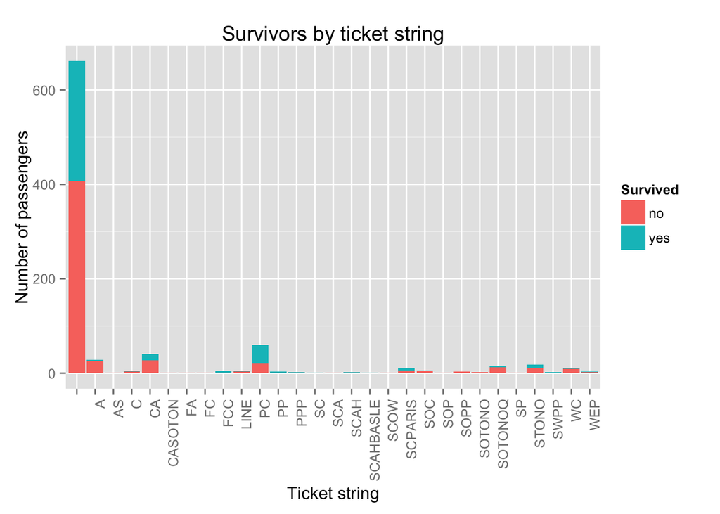

```r
g <- ggplot(data = d, aes(x=TicketString, fill=Survived))
g <- g + geom_bar()
g <- g + labs(title="Survivors by ticket string", x="Ticket string", y="Number of passengers")
g <- g + scale_fill_discrete(name="Survived", labels=c("no", "yes"))
g <- g + theme(axis.text.x = element_text(angle = 90, hjust = 1))
g
```

I’m not sure I’ll use this feature in my model.

Maybe check only the survival rate difference between passenger with letters in their tickets against passenger with only numbers:

```r
d %>%
    filter(TicketString == "") %>%
    group_by(Survived) %>%
    summarise(n = n()) %>%
    mutate(survivalrate = n / sum(n))
```

```
## Source: local data frame [2 x 3]
##
##   Survived     n survivalrate
##     (fctr) (int)        (dbl)
## 1        0   407    0.6157337
## 2        1   254    0.3842663
```

```r
d %>%
    filter(TicketString != "") %>%
    group_by(Survived) %>%
    summarise(n = n()) %>%
    mutate(survivalrate = n / sum(n))
```

```
## Source: local data frame [2 x 3]
##
##   Survived     n survivalrate
##     (fctr) (int)        (dbl)
## 1        0   142    0.6173913
## 2        1    88    0.3826087
```

Ok.. not much difference here between ticket holders with and without strings in their ticket. Maybe the ticket number is more useful. let’s convert it to a numeric and plot the survival rate:

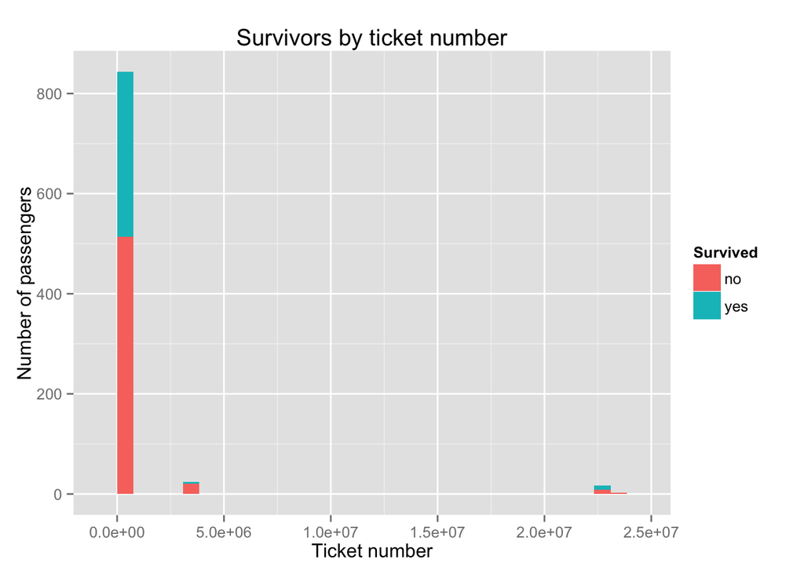

```r
d$TicketNumber <- as.numeric(d$TicketNumber)
g <- ggplot(data = d, aes(x=TicketNumber, fill=Survived))
g <- g + geom_bar()
g <- g + labs(title="Survivors by ticket number", x="Ticket number", y="Number of passengers")
g <- g + scale_fill_discrete(name="Survived", labels=c("no", "yes"))
g
```

Here we can see that ticket holders with a small ticket numbers are among the vast majority of the passengers. But this doesn’t help. Maybe we can check the first digit of the ticket, this may be related to the location on the boat.

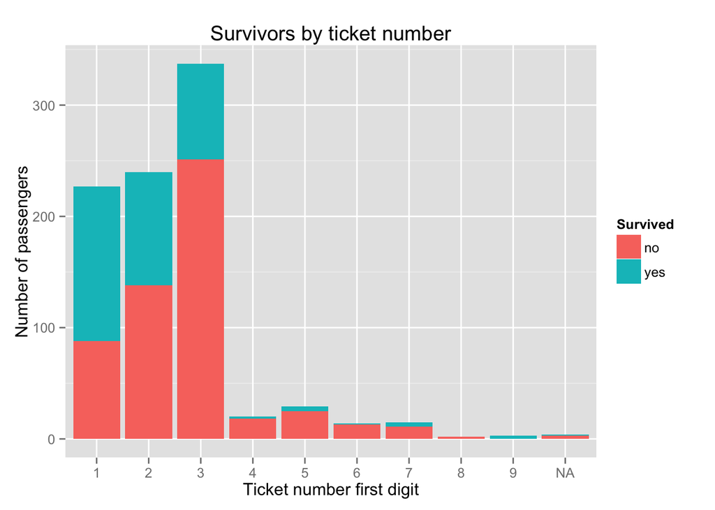

```r
d <- d %>%
    mutate('TicketDigit' = as.factor(gsub('(\\d)\\d*\\$?', '\\1', TicketNumber, perl=TRUE)))
g <- ggplot(data = d, aes(x=TicketDigit, fill=Survived))
g <- g + geom_bar()
g <- g + labs(title="Survivors by ticket number", x="Ticket number first digit", y="Number of passengers")
g <- g + scale_fill_discrete(name="Survived", labels=c("no", "yes"))
g
```

It looks like the first digit is actually relevant. The lower this number, the higher the survival rate.

We’ll see if we can use all these information when preprocessing the data in the next steps. For now, that’s all the information I can draw from the Ticket feature.

### Fare

That’s also probabely a proxy for the passenger class, hence for the social status. First let’s convert it to numeric. We have 0.00 values, which seem a bit strange.

Let’s ignore these for this exploration. We can fill them later on if needed. FOr example, using the mean of the class fare, that would work.

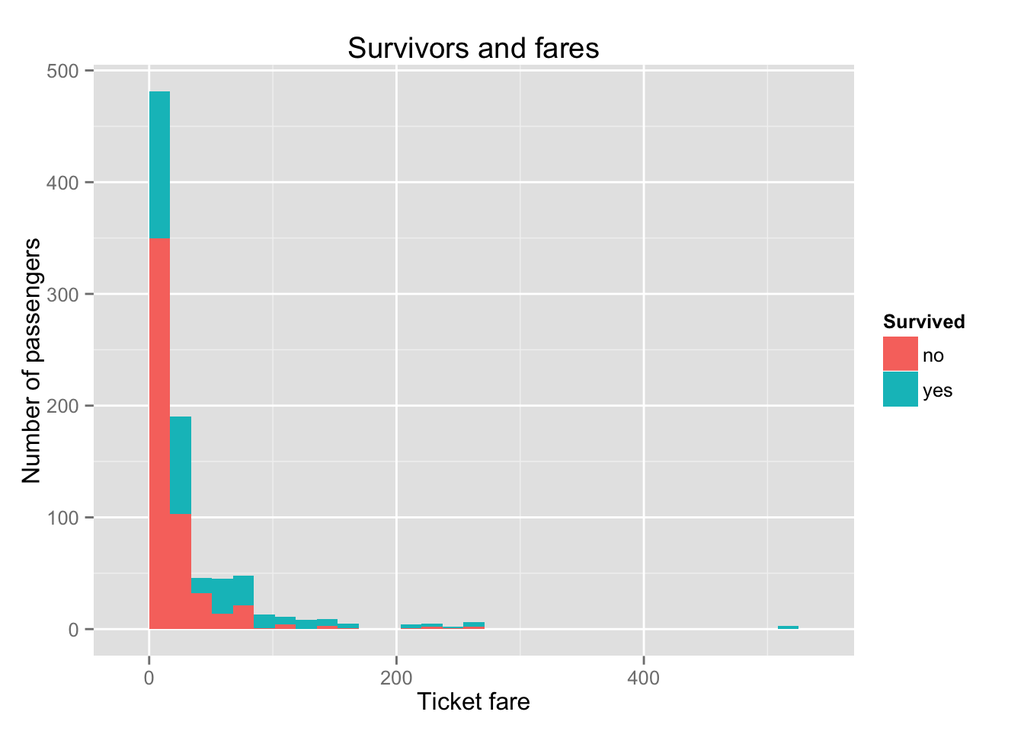

```r
d <- df %>% filter(Fare != 0)
d$Fare <- as.numeric(as.character(d$Fare))
g <- ggplot(data = d, aes(x=Fare, fill=Survived))
g <- g + geom_bar()
g <- g + labs(title="Survivors and fares", x="Ticket fare", y="Number of passengers")
g <- g + scale_fill_discrete(name="Survived", labels=c("no", "yes"))
g
```

Also 3 passengers paid more than 400, and they all survived. Let’s look in more details at the lower fares.

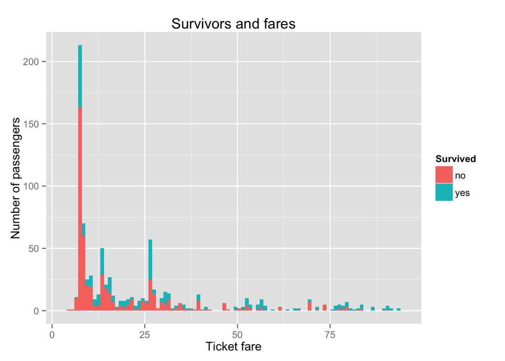

```r
g <- ggplot(data = d %>% filter(Fare < 100), aes(x=Fare, fill=Survived))
g <- g + geom_bar(binwidth=1)
g <- g + labs(title="Survivors and fares", x="Ticket fare", y="Number of passengers")
g <- g + scale_fill_discrete(name="Survived", labels=c("no", "yes"))
g
```

Clearly, a big proportion of the lower fares died. We cannot ignore this feature for our model, maybe we can fill in the missing values by using the median price (the mean is a bit skewed because of those very expensive passengers).

### Cabin number

This one is a bit complicated because of the amount of missing values.

```r
(df %>% filter(Cabin == "") %>% count)$n
```

```
## [1] 687
```

So.. we can still have a look, maybe at the floor (assuming this is the meaning of the letter) and the survival rate for each floor.

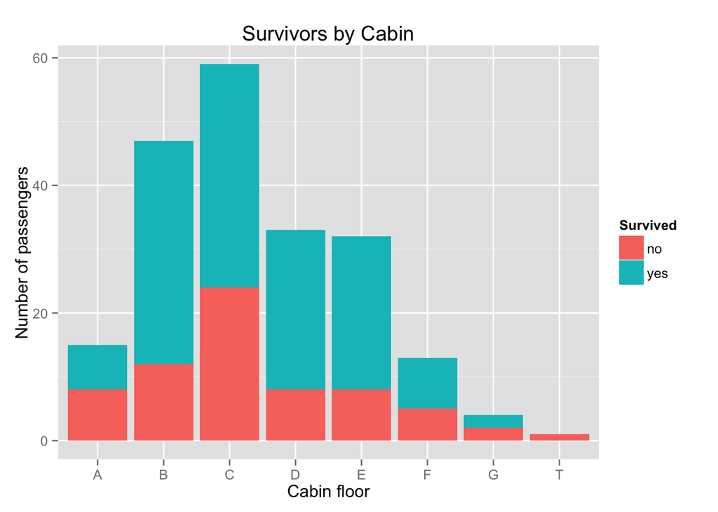

```r
d <- df %>%
    filter(Cabin != "") %>%
    mutate(Cabin = gsub("^(\\w).*$", "\\1", Cabin)) %>%
    select(Cabin, Survived)
g <- ggplot(data = d, aes(x=Cabin, fill=Survived))
g <- g + geom_bar(binwidth=1)
g <- g + labs(title="Survivors by Cabin", x="Cabin floor", y="Number of passengers")
g <- g + scale_fill_discrete(name="Survived", labels=c("no", "yes"))
g
```

```r
dd <- d %>%
    group_by(Cabin, Survived) %>%
    summarise(n = n()) %>%
    mutate(survivalrate = n / sum(n)) %>%
    select(Survived, Cabin, survivalrate) %>%
    spread(Survived, survivalrate)
colnames(dd) <-  c('floor', 'died', 'survived')
dd
```

```
## Source: local data frame [8 x 3]
##
##   floor      died  survived
##   (chr)     (dbl)     (dbl)
## 1     A 0.5333333 0.4666667
## 2     B 0.2553191 0.7446809
## 3     C 0.4067797 0.5932203
## 4     D 0.2424242 0.7575758
## 5     E 0.2500000 0.7500000
## 6     F 0.3846154 0.6153846
## 7     G 0.5000000 0.5000000
## 8     T 1.0000000        NA
```

If the letter indicates the floor or deck, maybe the number indicates the position of the cabin.

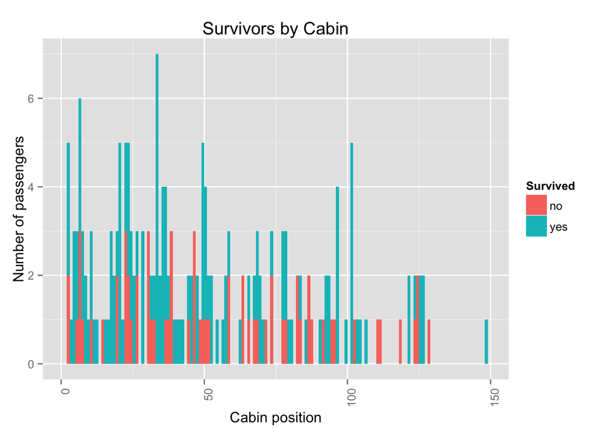

```r
d <- df %>%
    filter(Cabin != "") %>%
    filter(grepl("\\d", Cabin)) %>%
    mutate(Cabin = as.numeric(gsub("\\D+(\\d+) ?.*", "\\1", Cabin, perl=TRUE))) %>%
    select(Cabin, Survived) %>%
    arrange(Cabin)
g <- ggplot(data = d, aes(x=Cabin, fill=Survived))
g <- g + geom_bar(binwidth=1)
g <- g + labs(title="Survivors by Cabin", x="Cabin position", y="Number of passengers")
g <- g + scale_fill_discrete(name="Survived", labels=c("no", "yes"))
g <- g + theme(axis.text.x = element_text(angle = 90, hjust = 1))
g
```

We can maybe see a pattern here, with chunks of full survival and chunks of full not-survival. It’s not a linear progression, so we can group the position into bins to make it easier to use.

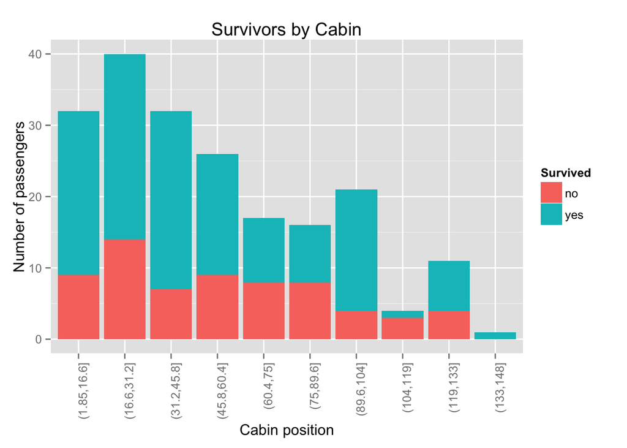

```r
d <- df %>%
    filter(Cabin != "") %>%
    filter(grepl("\\d", Cabin)) %>%
    mutate(Cabin = as.numeric(gsub("\\D+(\\d+) ?.*", "\\1", Cabin, perl=TRUE))) %>%
    mutate(Position = cut(Cabin, 10)) %>%
    select(Position, Survived) %>%
    arrange(Position)
g <- ggplot(data = d, aes(x=Position, fill=Survived))
g <- g + geom_bar(binwidth=1)
g <- g + labs(title="Survivors by Cabin", x="Cabin position", y="Number of passengers")
g <- g + scale_fill_discrete(name="Survived", labels=c("no", "yes"))
g <- g + theme(axis.text.x = element_text(angle = 90, hjust = 1))
g
```

Ok that can be used in the model.

Maybe just the fact to have a cabin number means you have more chance to survive ?

```r
dd <- df %>%
    mutate(hascabin = Cabin != "") %>%
    group_by(hascabin, Survived) %>%
    summarise(n = n()) %>%
    mutate(survivalrate = n / sum(n)) %>%
    select(hascabin, Survived, survivalrate) %>%
    spread(Survived, survivalrate)
colnames(dd) <-  c('has cabin', 'died', 'survived')
dd
```

```
## Source: local data frame [2 x 3]
##
##   has cabin      died  survived
##       (lgl)     (dbl)     (dbl)
## 1     FALSE 0.7001456 0.2998544
## 2      TRUE 0.3333333 0.6666667
```

Well looks like having a cabin number gives you a very high chance of survival (66%) compard to not having one (30%). So we can probabely change this feature to a simple boolean value.

Also the number of cabin may matter:

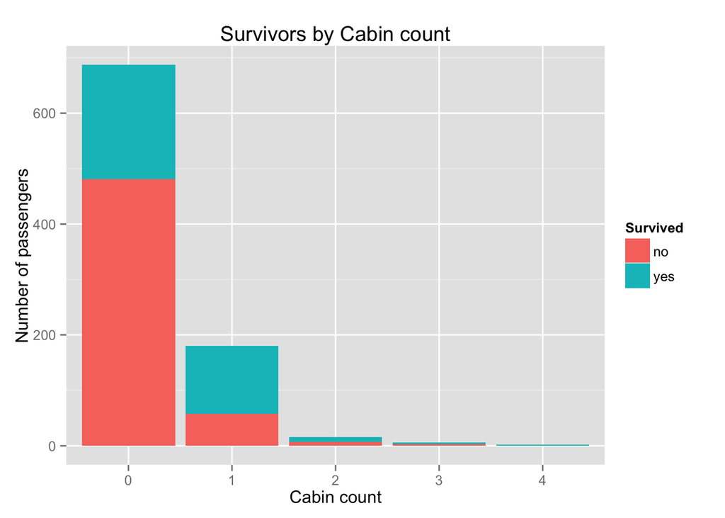

```r
d <- df %>%
    mutate('cabinCount' = as.factor(sapply(gregexpr("[[:alpha:]]+", Cabin), function(x) sum(x > 0)))) %>%
    select(cabinCount, Survived)
g <- ggplot(data = d, aes(x=cabinCount, fill=Survived))
g <- g + geom_bar(binwidth=1)
g <- g + labs(title="Survivors by Cabin count", x="Cabin count", y="Number of passengers")
g <- g + scale_fill_discrete(name="Survived", labels=c("no", "yes"))
g
```

Indeed, the more cabins, the more chance of survival.

### Port of Embarkation

This feature is a factor with 3 levels:

```r
levels(df$Embarked)
```

```
## [1] ""  "C" "Q" "S"
```

With C = Cherbourg, Q = Queenstowna dn S = Southampton. 2 Passenger have no information regarding their port of embarkation, they both survived. I don’t think that’s relevant.

Let’s look at the survival rate per port:

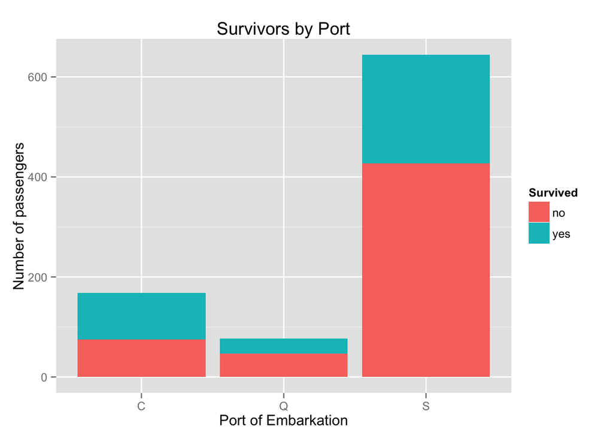

```r
d <- df %>% filter(Embarked != "") %>% select(Survived, Embarked)
g <- ggplot(data = d, aes(x=Embarked, fill=Survived))
g <- g + geom_bar(binwidth=1)
g <- g + labs(title="Survivors by Port", x="Port of Embarkation", y="Number of passengers")
g <- g + scale_fill_discrete(name="Survived", labels=c("no", "yes"))
g
```

It’s not really evident if the port of embarkation has an impact on the passenger’s faith. Looks like better odds for passenger coming from Cherbourg.

```r
dd <- df %>%
    filter(Embarked != "") %>%
    select(Survived, Embarked) %>%
    group_by(Embarked, Survived) %>%
    summarise(n = n()) %>%
    mutate(survivalrate = n / sum(n)) %>%
    select(Embarked, Survived, survivalrate) %>%
    spread(Survived, survivalrate)
colnames(dd) <- c("Port or embarkation", "died", "survived")
dd
```

```
## Source: local data frame [3 x 3]
##
##   Port or embarkation      died  survived
##                (fctr)     (dbl)     (dbl)
## 1                   C 0.4464286 0.5535714
## 2                   Q 0.6103896 0.3896104
## 3                   S 0.6630435 0.3369565
```

So we can see that passengers embarked in Cherbourg have 55% chance of surviving, that’s pretty good compared to the 2 other embarcation ports.